# Hands-on Exercise 5a: Creating Ternary Plot with R

Author

Htet Kay Khaing

Published

May 9, 2026

Modified

May 10, 2026

## 5.1 Overview

Ternary plots are a way of displaying the distribution and variability of three-part compositional data. (For example, the proportion of aged, economy active and young population or sand, silt, and clay in soil.) Its display is a triangle with sides scaled from 0 to 1. Each side represents one of the three components. A point is plotted so that a line drawn perpendicular from the point to each leg of the triangle intersect at the component values of the point.

In this section, we will learn how to build ternary plot programmatically using R for visualising and analysing population structure of Singapore.

This section consists of four steps:

- Install and launch **tidyverse** and **ggtern** packages.
- Derive three new measures using *mutate()* function of **dplyr** package.
- Build a static ternary plot using *ggtern()* function of **ggtern** package.
- Build an interactive ternary plot using *plot-ly()* function of **Plotly R** package.

## 5.2 Installing and launching R packages

For this secion, two main R packages will be used, they are:

- [**ggtern**](http://www.ggtern.com/), a ggplot extension specially designed to plot ternary diagrams. The package will be used to plot static ternary plots.
- [**Plotly R**](https://plot.ly/r/), an R package for creating interactive web-based graphs via plotly’s JavaScript graphing library, plotly.js . The **plotly R** libary contains the *ggplotly* function, which will convert **ggplot2** figures into a Plotly object. We will also need to ensure that selected **tidyverse** family packages namely: **readr, dplyr** and **tidyr** are also installed and loaded.

The code chunks below will accomplish the task.

```r
pacman::p_load(plotly, ggtern, tidyverse)
```

## 5.3 Data Preparation

### 5.3.1 The data

For the purpose of this section, the [Singapore Residents by Planning AreaSubzone, Age Group, Sex and Type of Dwelling, June 2000-2018](https://www.singstat.gov.sg/find-data/search-by-theme/population/geographic-distribution/latest-data) data will be used. The data set has been downloaded and included in the data sub-folder of this folder. It is called *respopagsex2000to2018_tidy.csv* and is in csv file format.

### 5.3.2 Importing Data

To important *respopagsex2000to2018_tidy.csv* into R, *read_csv()* function of **readr** package will be used.

```r
#Reading the data into R environment
pop_data <- read_csv("data/respopagsex2000to2018_tidy.csv")
```

### 5.3.3 Preparing the Data

Next, use the *mutate()* function of **dplyr** package to derive three new measures, namely: young, active, and old.

```r
#Deriving the young, economy active and old measures
agpop_mutated <- pop_data %>%
  mutate(`Year` = as.character(Year))%>%
  spread(AG, Population) %>%
  mutate(YOUNG = rowSums(.[4:8]))%>%
  mutate(ACTIVE = rowSums(.[9:16]))  %>%
  mutate(OLD = rowSums(.[17:21])) %>%
  mutate(TOTAL = rowSums(.[22:24])) %>%
  filter(Year == 2018)%>%
  filter(TOTAL > 0)
```

## 5.4 Plotting Ternary Diagram with R

### 5.4.1 Plotting a static ternary diagram

Use *ggtern()* function of **ggtern** package to create a simple ternary plot.

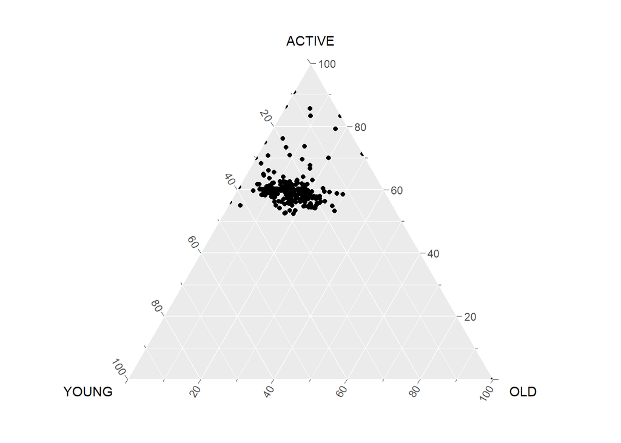

```r
#Building the static ternary plot
ggtern(data=agpop_mutated,aes(x=YOUNG,y=ACTIVE, z=OLD)) +
  geom_point()
```

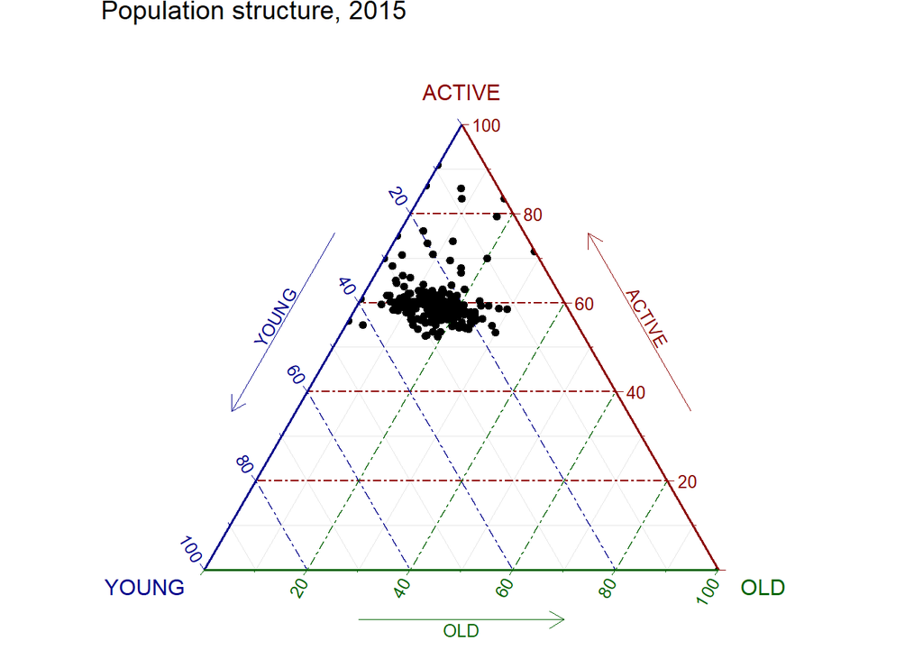

```r
#Building the static ternary plot
ggtern(data=agpop_mutated, aes(x=YOUNG,y=ACTIVE, z=OLD)) +
  geom_point() +
  labs(title="Population structure, 2015") +
  theme_rgbw()
```

### 5.4.2 Plotting an interative ternary diagram

The code below create an interactive ternary plot using *plot_ly()* function of **Plotly R**.

```r
# reusable function for creating annotation object
label <- function(txt) {
  list(
    text = txt,
    x = 0.1, y = 1,
    ax = 0, ay = 0,
    xref = "paper", yref = "paper",
    align = "center",
    font = list(family = "serif", size = 15, color = "white"),
    bgcolor = "#b3b3b3", bordercolor = "black", borderwidth = 2
  )
}

# reusable function for axis formatting
axis <- function(txt) {
  list(
    title = txt, tickformat = ".0%", tickfont = list(size = 10)
  )
}

ternaryAxes <- list(
  aaxis = axis("Young"),
  baxis = axis("Active"),
  caxis = axis("Old")
)

# Initiating a plotly visualization
plot_ly(
  agpop_mutated,
  a = ~YOUNG,
  b = ~ACTIVE,
  c = ~OLD,
  color = I("black"),
  type = "scatterternary"
) %>%
  layout(
    annotations = label("Ternary Markers"),
    ternary = ternaryAxes
  )
```

[interactive chart not shown]